# COMPSCIX 415.2 Homework 5/Midterm

Lionel Armstrong

February 28, 2018

```r
library(mdsr)
library(tidyverse)
library(dbplyr)
library(ggplot2)
```

https://github.com/lionelja/compscix-415-2-assignments

# RStudio and R Markdown (3 points)

*1.Use markdown headers in your document to clearly separate each midterm question and add a table of contents to your document.*

# The tidyverse packages (3 points)

By now youâve used at least five different packages from the tidyverse for plotting, data munging, reshaping data, importing/exporting data, and using tibbles (the tibble package is used for this without you even realizing itâs there).

*1. Can you name which package is associated with each task below?*

Plotting - Data munging/wrangling - Reshaping (speading and gathering) data - Importing/exporting data -*

##### ANSWER:

The ggplot2 package is used for plotting data. The dplyr package is used for data mungung/wrangling. The tidyr package is used for reshaping data. The readr package is used for importing/exporting data.

*2. Now can you name two functions that youâve used from each package that you listed above for these tasks?*

Plotting - Data munging/wrangling - Reshaping data - Importing/exporting data (note that readRDS and saveRDS are base R functions) -

##### ANSWER:

Two ggplot2 functions I’ve used are geom_smooth() and geom_bar(). Two dplyr functions I’ve used are select() and filter(). Two tidyr funtions I’ve used are gather() and spread(). Two readr functions I’ve used are read_csv() and write_csv().

# R Basics (1.5 points)

*1. Fix this code with the fewest number of changes possible so it works:*  
My_data.name___is.too00ooLong! <- c( 1 , 2 , 3 )

##### ANSWER:

Underscores and periods are the only valid special characters in a variable. Removing the explanation point make the statement valid.

```r
My_data.name___is.too00ooLong <- c( 1 , 2   , 3 )
```

*2. Fix this code so it works:*  
my_string <- C(‘has’, ‘an’, ‘error’, ‘in’, ‘it’)

##### ANSWER:

The components of a vector is designated with a capital “C” isn’t valid. This should be a lower case “c”.

```r
my_string <- c('has','an','error','in', 'it')
```

*3. Look at the code below and comment on what happened to the values in the vector.*

my_vector <- c(1, 2, ‘3’, ‘4’, 5) my_vector ## [1] “1” “2” “3” “4” “5”

##### ANSWER:

The components of a vector must be all of the same type. When the character type component ‘3’ is encounter all components become character type.

# Data import/export (3 points)

*1. Download the rail_trail.txt file from Canvas (in the Midterm Exam section here) and successfully import it into R. Prove that it was imported successfully by including your import code and taking a glimpse of the result.*

##### ANSWER:

```r
myfile='C:/Rdata/rail_trail.txt'
my_data <- read_delim(file = myfile, delim='|')
glimpse(my_data)
```

```
## Observations: 90
## Variables: 10
## $ hightemp   <int> 83, 73, 74, 95, 44, 69, 66, 66, 80, 79, 78, 65, 41,...
## $ lowtemp    <int> 50, 49, 52, 61, 52, 54, 39, 38, 55, 45, 55, 48, 49,...
## $ avgtemp    <dbl> 66.5, 61.0, 63.0, 78.0, 48.0, 61.5, 52.5, 52.0, 67....
## $ spring     <int> 0, 0, 1, 0, 1, 1, 1, 1, 0, 0, 0, 1, 1, 0, 0, 1, 0, ...
## $ summer     <int> 1, 1, 0, 1, 0, 0, 0, 0, 1, 1, 1, 0, 0, 0, 0, 0, 1, ...
## $ fall       <int> 0, 0, 0, 0, 0, 0, 0, 0, 0, 0, 0, 0, 0, 1, 1, 0, 0, ...
## $ cloudcover <dbl> 7.6, 6.3, 7.5, 2.6, 10.0, 6.6, 2.4, 0.0, 3.8, 4.1, ...
## $ precip     <dbl> 0.00, 0.29, 0.32, 0.00, 0.14, 0.02, 0.00, 0.00, 0.0...
## $ volume     <int> 501, 419, 397, 385, 200, 375, 417, 629, 533, 547, 4...
## $ weekday    <int> 1, 1, 1, 0, 1, 1, 1, 0, 0, 1, 1, 1, 1, 1, 1, 1, 0, ...
```

*2. Export the file into an R-specific format and name it ârail_trail.rdsâ. Make sure you define the path correctly so that you know where it gets saved. Then reload the file. Include your export and import code and take another glimpse.*

##### ANSWER:

```r
saveRDS(my_data, file='c:/RData/rail_trail.rds')
rds_file='C:/Rdata/rail_trail.rds'
my_rds_data <- readRDS ('C:/Rdata/rail_trail.rds')
glimpse(my_rds_data)
```

```
## Observations: 90
## Variables: 10
## $ hightemp   <int> 83, 73, 74, 95, 44, 69, 66, 66, 80, 79, 78, 65, 41,...
## $ lowtemp    <int> 50, 49, 52, 61, 52, 54, 39, 38, 55, 45, 55, 48, 49,...
## $ avgtemp    <dbl> 66.5, 61.0, 63.0, 78.0, 48.0, 61.5, 52.5, 52.0, 67....
## $ spring     <int> 0, 0, 1, 0, 1, 1, 1, 1, 0, 0, 0, 1, 1, 0, 0, 1, 0, ...
## $ summer     <int> 1, 1, 0, 1, 0, 0, 0, 0, 1, 1, 1, 0, 0, 0, 0, 0, 1, ...
## $ fall       <int> 0, 0, 0, 0, 0, 0, 0, 0, 0, 0, 0, 0, 0, 1, 1, 0, 0, ...
## $ cloudcover <dbl> 7.6, 6.3, 7.5, 2.6, 10.0, 6.6, 2.4, 0.0, 3.8, 4.1, ...
## $ precip     <dbl> 0.00, 0.29, 0.32, 0.00, 0.14, 0.02, 0.00, 0.00, 0.0...
## $ volume     <int> 501, 419, 397, 385, 200, 375, 417, 629, 533, 547, 4...
## $ weekday    <int> 1, 1, 1, 0, 1, 1, 1, 0, 0, 1, 1, 1, 1, 1, 1, 1, 0, ...
```

# Visualization (6 points)

##### ANSWER:

The bubble size is at the lower end of the spectrum of good visual cues. The age dimension is omitted for men and women graph. The numeric values in the center of the bubble isn’t clear whether not it’s an percentage for two reason (1) not labeled with %, (2) the total percentage value for a nominal dimension such as sex should equal 100%.

##### ANSWER:

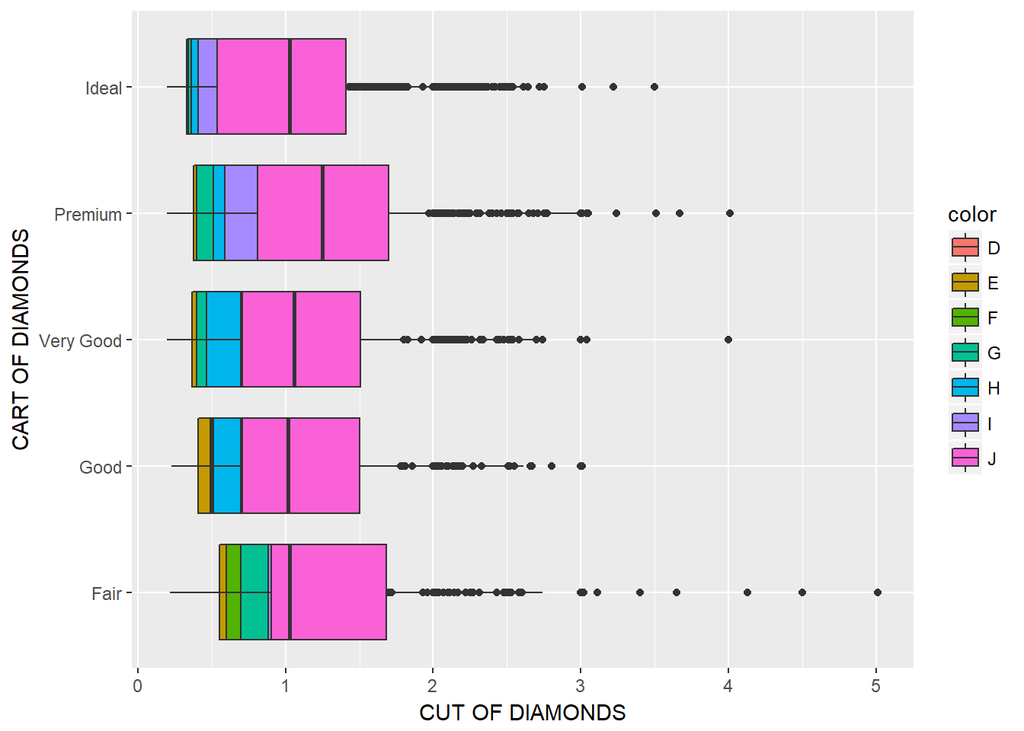

```r
ggplot(data = diamonds, mapping = aes(y = carat, x = cut, fill= color)) +
  xlab('CART OF DIAMONDS') + ylab('CUT OF DIAMONDS') +
  geom_boxplot(position = 'identity') +
  coord_flip()
```

*3. The previous graphic is not very useful. We can make it much more useful by changing one thing about it. Make the change and plot it again.*

##### ANSWER:

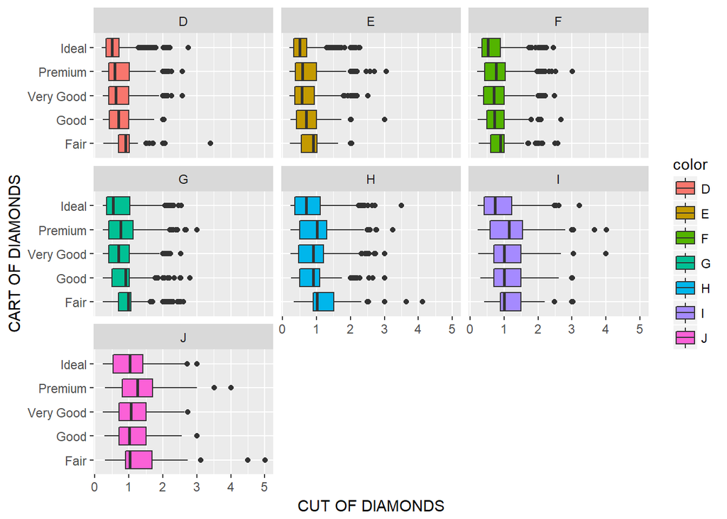

```r
ggplot(data = diamonds, mapping = aes(y = carat, x = cut, fill= color)) +
  xlab('CART OF DIAMONDS') + ylab('CUT OF DIAMONDS') +
  geom_boxplot(position = 'identity') +
  coord_flip() +
   facet_wrap(~ color)
```